# Normal distribution

#### Probability density function

Plotting a normal distribution for values between -5 and 5. *dnorm()* is the normal probability density function.

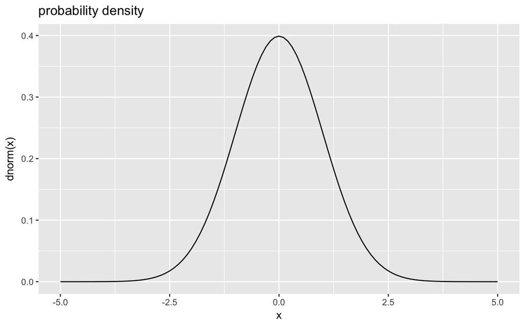

```r
# notice that we do not specify a data set, use implicitly through the mapping.
x <- seq(-5,5,0.1)
ggplot() + geom_line(aes(x=x, y=dnorm(x))) + ggtitle("probability density")
```

#### How to interpret y, the probability density?

We have to keep in mind:

- the area under the curve equals 1
- the probability for any exact point on the curve is 0
- choose an interval on x, the probability of a point falling within is the area of that curve section

#### The cumulative probability function

- the integration gives us the cumulative probability function. y is the probability that a random point is left of a particular point on the curve
- remember that the normal curve is asymptotic, actually never touches y = 0 or 1

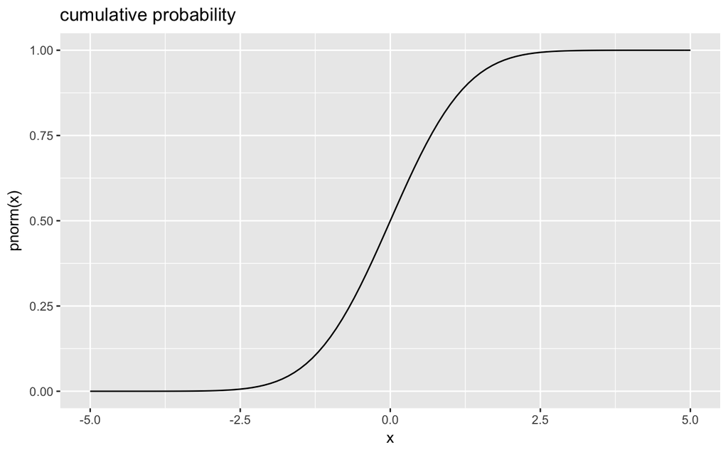

```r
ggplot() + geom_line(aes(x=x, y=pnorm(x))) + ggtitle("cumulative probability")
```

#### Generating normally distributed, random values:

- try choosing larger / smaller numbers and running the function several times.
- notice the mean, median, sd values of the sample.
- we will superimpose a theoretical normal curve for comparison

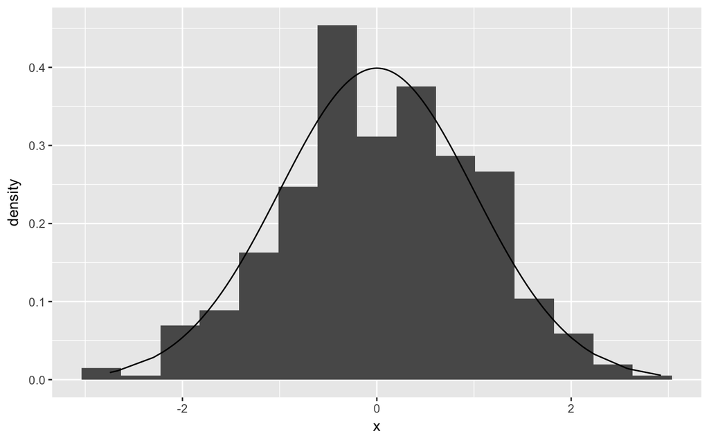

```r
x <- rnorm(n = 500)
ggplot() +
  geom_histogram(aes(x, y= ..density..), bins= 15) +
   geom_line(aes(x=x, y=dnorm(x)))
```

```r
summary(x)
```

```
    Min.  1st Qu.   Median     Mean  3rd Qu.     Max.
-2.74725 -0.58984  0.09075  0.06841  0.78109  2.92382
```

```r
sd(x)
```

```
[1] 0.991731
```

We can compare the generated, imperfect sample with the theoretical normal function. This can be done with a Quantile-Quantile plot (QQplot) that compares both distributions along their x axis. A perfect match would give a straight diagonal line. The sample histogram can look terrible, but the QQ plot shows it is not so far off.

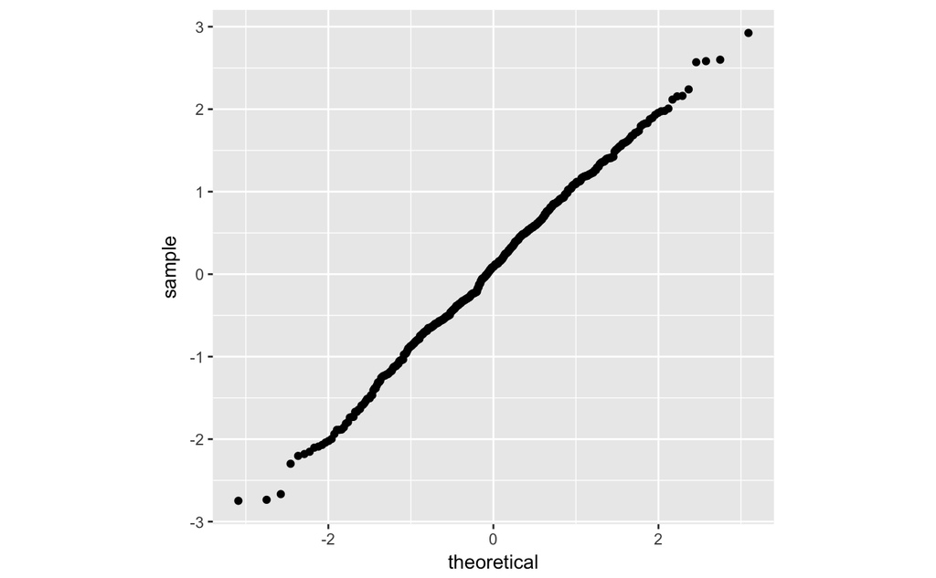

```r
# coord_fixed() gives us a 1:1 aspect ratio
ggplot() + geom_qq(aes(sample = x)) + coord_fixed()
```

### Z-scores and standardization

The sample can be standardized, so it can be compared to the normal distribution. After standarziation, the raw observations are converted into z-scores, centered on the mean and using standard deviations as a unit.

```r
# load Pearson's height data
height <- read.csv(file = "http://www.randomservices.org/random/data/Pearson.txt",sep = "\t")
height <- height$Son
summary(height)
```

```
   Min. 1st Qu.  Median    Mean 3rd Qu.    Max.
  58.50   66.90   68.60   68.68   70.50   78.40
```

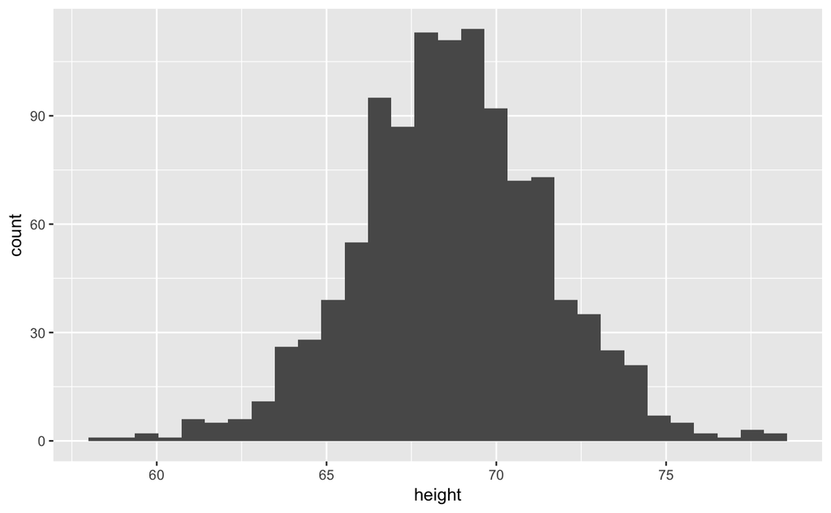

```r
h.sd <- sd(height)
h.mean <- mean(height)
# z-scores of height
h.z <- (height - h.mean) / h.sd
# both histograms look a bit different because of binning
ggplot() + geom_histogram(aes(x=height))
```

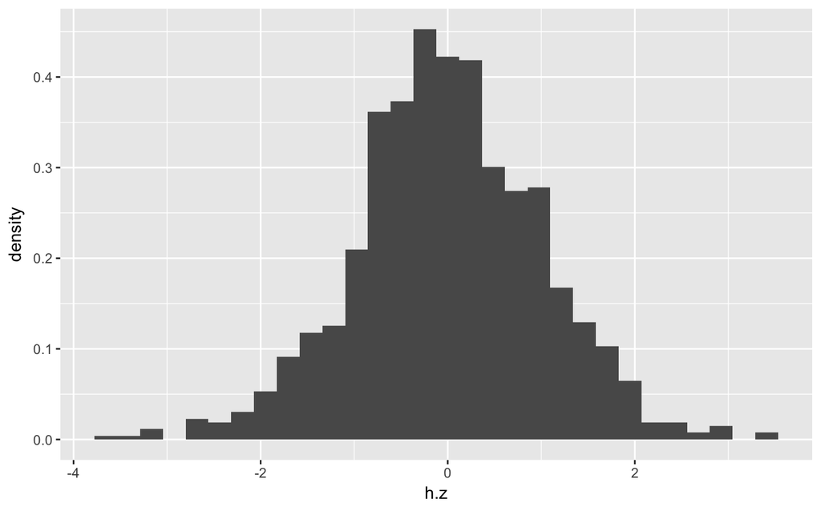

```r
ggplot()+ geom_histogram(aes(x=h.z, y= ..density..))
```

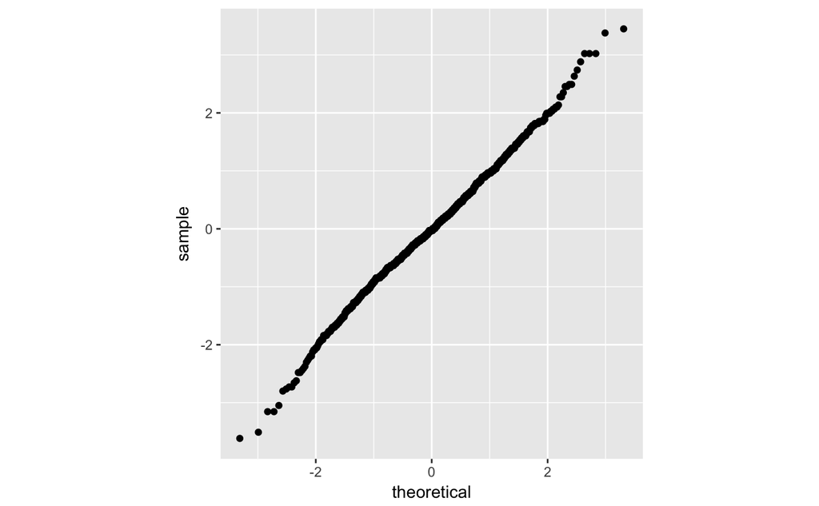

```r
# is it normally distributed?
ggplot() + geom_qq(aes(sample = h.z)) + coord_fixed()
```

Looks good! Knowing that the sample is normally distributed, we can now use the cumulative normal probability function to predict the probability that a particular height occurs.

```r
# probability of height less than 70?
pnorm(70, mean = h.mean, sd = h.sd)
```

```
[1] 0.6798272
```

```r
# probability of height more than 70?
1 - pnorm(70, mean = h.mean, sd = h.sd)
```

```
[1] 0.3201728
```

```r
# between 70 and 75?
pnorm(75, mean = h.mean, sd = h.sd) - pnorm(70, mean = h.mean, sd = h.sd)
```

```
[1] 0.3077135
```

```r
# outside 70 and 75?
1- (pnorm(75, mean = h.mean, sd = h.sd) - pnorm(70, mean = h.mean, sd = h.sd))
```

```
[1] 0.6922865
```

Lets look again at the standardized sample distribution.

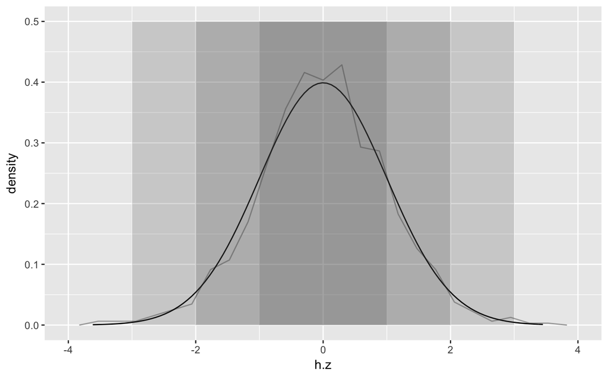

```r
ggplot(data = data.frame(h.z)) +
  geom_freqpoly(aes(x= h.z, y = ..density.. ), bins = 25, color = "darkgray") +
  stat_function(fun = dnorm, geom = "line", args = list(mean = 0, sd = 1)) +
  annotate(geom = "rect", xmin = c(-3,-2,-1), xmax = c(3,2,1), ymin = 0, ymax = 0.5, alpha = 0.2)
```

Standardized intervals have defined probabilities:

```r
pnorm(1) - pnorm(-1) # p for a value between sd -1 and 1 is 0.6826895 (~68%)
```

```
[1] 0.6826895
```

```r
pnorm(2) - pnorm(-2) # p for a value between sd -2 and 2 is 0.9544997 (~95%)
```

```
[1] 0.9544997
```

```r
pnorm(3) - pnorm(-3) # p for a value between sd -3 and 3 is 0.9973002 (~99%)
```

```
[1] 0.9973002
```

We can also calculate the boundaries of height for different z scores.

```r
c(-2,-1,1,2) * h.sd + h.mean
```

```
[1] 63.05184 65.86804 71.50042 74.31662
```